# Plots e RedeR

Kelin G. deOliveira, Mauro A. A. Castro

2018-07-13

# 1 Introdução

Plots podem ser feitos de várias maneiras em linguagem R, uma das funções mais utilizadas é o plot, que compreende uma família de funções genéricas presentes no núcleo do R, ou seja, vêm junto do R sem necessitar a instalação de um pacote específico. Dependendo do que se deseja, outras funções para plotar podem ser utilizadas, tornando possível a montagem de grafos diversos, como de pontos (scatter), regressão linear, de barras, histogramas, boxplots, etc.

Há formas mais avançadas de plotar utilizando o R (como através do pacote ggplot2), porém um conhecimento do sistema básico de gráficos é importante para construção do conhecimento. No entanto, para análise de dados em rede, vamos utilizar um derivado do ggplot2, o ggnet.

## 1.1 Iniciando com plots

Quando se trabalha com uma grande quantidade de dados, a representação destes em forma dde grafos é extremamente necessária a fim de obter os insights que só podem ser vistos por abordagens mais abrangentes.  
Para exemplificar o uso de plots para dados biológicos, vamos carregar e visualizar um dataset jś presente no R, o iris.

```r
data("iris")
View(iris)
```

Iris contém os dados de comprimento e largura da sépala e da pétala de 150 plantas de 3 espécies diferentes (Iris setosa, versicolor e virginica).

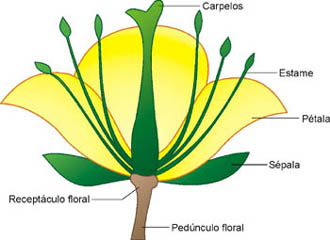

Figura 2 - Representação da estrutura de uma flor. A sépala é a região da flor que fornece sustentação às pétalas.

### 1.1.1 Scatter Plot

O scatter plot (gráfico de dispersão) é útil em comparações entre duas variáveis contínuas. Para plotar um scatter plot da relação entre o comprimento e a largura das pétalas, basta utilizar a função plot.

```r
plot(x = iris$Petal.Length,
     y = iris$Petal.Width,
     main = "Pétala - largura vs comprimento") # título
```

Para saber qual medida vem de qual espécie e se estas se agrupam, podemos alterar o tipo de ponto para cada espécie ou a cor destes.

Alterando tipos de pontos do scatter plot:

```r
plot(x = iris$Petal.Length,
     y = iris$Petal.Width,
     pch = c(21,22,23)[unclass(iris$Species)], # 'plotting character' = tipo do ponto (? points)
     main = "Pétala - largura vs comprimento")
```

Alterando cor:

```r
plot(x = iris$Petal.Length,
     y = iris$Petal.Width,
     pch = 21,
     bg = c("red","green3","blue")[unclass(iris$Species)], # 'background' color, só col muda a cor da borda
     main = "Pétala - largura vs comprimento")
legend("bottomright", # posição da legenda
       legend = levels(iris$Species), # o que vai na legenda
       pt.bg = c("red","green3","blue"), # cores dos pontos
       pch = 21,
       bty = "n") # 'box type', n é nenhuma ('none')
abline(lm(Petal.Width~Petal.Length, data=iris), col="grey30") # adiciona uma linha de regressão linear
```

Para ver como que as variáveis se comportam entre si de uma maneira mais gráfica, é possível criar um scatter plot de pares, que mostra a disposição dos pontos conforme cada combinação de dois fatores (Draftsman’s design).

```r
pairs(iris[1:4],
      main = "Relação par a par",
      pch = 21,
      bg = c("red", "green3", "blue")[unclass(iris$Species)])
```

### 1.1.2 Histograma

O histograma avalia a distribuição dos seus dados em diferentes intervalos. Para ver se os dados seguem uma distribuição normal, o histograma é de grande utilidade:

```r
hist(iris$Sepal.Width)
hist(iris$Petal.Length)
```

O gráfico pode ser refinado mudando o número de intervalos:

```r
hist(iris$Sepal.Length, breaks = 6)
```

### 1.1.3 Boxplot

O boxplot (diagrama de caixa) é útil quando temos uma variável contínua que deve ser comparada entre grupos (variável categórica). Por exemplo, um boxplot pode ser utilizado para comparar as diferenças entre as três espécies, por exemplo, como a largura da pétala.

```r
boxplot(iris$Petal.Width~iris$Species, iris$Species,
        col=c("pink", "yellow", "grey"),
        ylab="Largura da pétala") # 'y label', nome do eixo y
```

### 1.1.4 Barplot

O barplot é interessante quando queremos contar quantos elementos têm em cada grupo (frequência de variável categórica). Aqui, por exemplo, podemos mostrar quantas iris de cada espécie estão presentes no nosso dataframe.

```r
barplot(table(iris$Species))
```

### 1.1.5 Heatmaps

Torna visível a clusterização das espécies conforme determinadas características. No heatmap, podemos ver associação entre várias características e entre as observações ao mesmo tempo.

```r
library(pheatmap)
rownames(iris) <- 1:nrow(iris) # adiciona 'nomes' às amostras (1 a 150)
pheatmap(t(iris[,1:4]), # t de 'transpose' -> transpor a matriz
         annotation_col = data.frame(Species = iris$Species), # adicionar uma barra de anotação com info de espécie
         show_colnames = FALSE) # esconde nomes das colunas (1 a 150)
```

### 1.1.6 Gráfico de rede

Vamos supor que queremos visualizar uma rede de interações entre proteínas (rede PPI). A partir do STRINGdb, um banco de dados de interações proteína-proteína, importamos todas as relações (`esr1_ppi`). De lá, também adquirimos informações sobre as proteínas da rede (`prot_annot`). Para o receptor de estrogênio 1 (ESR1), esses dados estão armazenados em `ppi4esr1`.

```r
# Carrega os dados
data(ppi4esr1)
# Visualiza os dados no console
esr1_ppi
prot_annot
```

Há vários pacotes para visualizar redes – incluindo o RedeR, que foi desenvolvido pelo nosso grupo no Laboratório de Bioinformática e Biologia de Sistemas. Ele traz uma interface R e Java bastante poderosa para visualização e organização de redes de grande complexidade.

Porém, hoje iremos utilizar a função `ggnet2` e o pacote `network` para construir a rede. Iremos utilizar apenas as duas primeiras colunas de esr1_ppi, que contém os nomes das proteínas na ligação (ex.: Prot1 <-> Prot2; Prot1 <-> Prot3)

```r
# Chama as bibliotecas
library(network)
library(sna)
library(ggplot2)
library(GGally)

# Cria a rede
net <- network(as.matrix(esr1_ppi[,1:2]), directed = FALSE)
```

Agora que temos a rede, podemos plotá-la simplesmente com o comando

```r
ggnet2(net)
```

Porém isso não é muito informativo. Não sabemos qual vértice representa quem na rede e nada sobre as proteínas. Podemos adicionar essas informações usando a função `set.vertex.attribute`, já que cada proteína é um vértice (vertex ou node) de nossa rede. Em `prot_annot`, temos duas informações interessantes - a função resumida e o tamanho do transcrito para cada proteína.

```r
? set.vertex.attribute
# Adiciona a anotação resumida
set.vertex.attribute(net, "cell_function", esr1_annot$short_annot)
# Adiciona tamanho do transcrito
set.vertex.attribute(net, "transcript_length", esr1_annot$tlength)

ggnet2(net,
       label = TRUE, # mostra os nomes
       color = "cell_function", # mapeia cada função para uma cor do vértice
       size = "transcript_length", # mapeia comprimento do transcrito para tamanho do vértice
       palette = "Set2") + # muda a paleta de cores
guides(size = FALSE) # esconde a legenda de tamanho
```

Agora está melhor! Mas há mais uma informação que pode enriquecer nossa rede. Em `esr1_ppi`, temos um score para cada interação. Podemos visualizar a força da evidência da interação também na nossa rede mudando a largura da aresta (edge).

```r
? set.edge.attribute

# Adiciona score de evidência na aresta
set.edge.attribute(net, "interaction", esr1_ppi$combined_score * 1.3)

ggnet2(net,
       label = TRUE,
       color = "cell_function",
       size = "transcript_length",
       palette = "Set2",
       edge.size = "interaction", # mapeia score combinado à largura da aresta
       edge.color = "grey80") + # deixa as arestas cinza claro)
  guides(size = FALSE)
```

E voilà!

# 2 Lições Interativas

Quer colocar as novas habilidades em gráficos em prática? Volte ao swirl para treinar.  
Se você ainda não tem o pacote swirl carregado no teu ambiente, veja a sessão de Lições Interativas na vignette(“Intro”) para ver como fazer este passo.  
Para fazer a próxima lição, basta chamar a função novamente

```r
#Começa o curso
swirl()
```

De volta ao **curso Programação em R**, selecione a **lição “Gráficos Básicos”** para colocar em prática as tuas novas habilidades em plotar gráficos.